# Analyzing the Expansion of the Money Supply

Last updated: 2026-02-10

## Preliminary Work: Install/Load Packages

To try and ensure that this R Notebook will run successfully, we’ll use the [renv package](https://cran.r-project.org/web/packages/renv/index.html) to create a project-specific library of packages. This will allow us to install the packages that we need for this project without affecting any other projects that we may be working on. Additionally, the project library will track the specific versions of the dependency packages so that any updates to those packages will not break this project.

The code chunk below will first install the renv package if it is not already installed. Then we will load the package. Next, we’ll use the `restore()` function to install any packages listed in the renv.lock file. Once these packages are installed, we can load them into the R session using the `library()` commands. Below the code chunk, we’ll list out the packages that will be used in the project demo.

```
# Install renv package if not already installed
if(!"renv" %in% installed.packages()[,"Package"]) install.packages("renv")
# Load renv package
library(renv)
# Use restore() to install any packages listed in the renv.lock file
renv::restore(clean=TRUE, lockfile="../renv.lock")
# Load in the packages
library(fredr)
library(dplyr)
library(xts)
library(ggplot2)
library(stringi)
library(stringr)
library(rmarkdown)
```

- The [fredr package](https://cran.r-project.org/package=fredr) is an R package that wraps the [FRED API](https://fred.stlouisfed.org/docs/api/fred/) for easy importing of FRED data into R.
- The [dplyr package](https://cran.r-project.org/package=dplyr) package enables additional functionality for transforming data frames.
- The [xts package](https://cran.r-project.org/package=xts) allows for some additional time series functionality.
- The [ggplot2 package](https://cran.r-project.org/package=ggplot2) includes tools for generating graphics and visuals.
- The [rmarkdown package](https://cran.r-project.org/package=rmarkdown) is used to generate this R Notebook, along with the [stringi](https://cran.r-project.org/package=stringi and stringr packages for some additional string manipulation functionality.

Since the rmarkdown functionality is built into RStudio, this one is automatically loaded when we open the RStudio. So no need to use the `library()` function for this one. Another observation to make about the code chunk above is that it is labeled as ‘setup’, which is a special name, which the R Notebook will recognize and automatically run prior to running any other code chunk. This is useful for loading in packages and setting up other global options that will be used throughout the notebook.

Then if you wish to try and update the versions of the various R packages in the lock file, you can use the `renv::update()` function to update the packages in the project library. However, it is possible that these updates could break the code in this notebook. If so, you may need to adapt the code to work with the updated packages.

My recommendation is to first run through the code using the versions of the packages in the lock file. Then if you want to try and update the packages, you can do so and then run through the code again to see if it still works. If not, you can always revert back to the lock file versions using the `renv::restore()` function.

If you update the packages and get everything working successfully, then you can update the lock file using the `renv::snapshot()` function. This will update the lock file with the versions of the packages that are currently installed in the project library. Then you can commit the updated lock file to the repository so that others can use the updated versions of the packages.

## FRED Data Import

To access the FRED API, you must first create an account and [request an API key](https://fred.stlouisfed.org/docs/api/api_key.html). If you wish to run the code and replicate the results, you need to make an account, generate an API key, save it in a plain text file named “fredapikey”, and run this command. The `scan` function will load the text, and the `fredr_set_key` function will set the key for the `fredr` package.

```
fredr_set_key(scan("fredapikey", what="character"))
```

```
Read 1 item
```

```
M2 = fredr(
  series_id="M2SL",
  observation_start=as.Date("1959-01-01"),
  observation_end=as.Date(Sys.Date())
)
M1 = fredr(
  series_id="M1SL",
  observation_start=as.Date("1959-01-01"),
  observation_end=as.Date(Sys.Date())
)
C = fredr(
  series_id="CURRSL",
  observation_start=as.Date("1959-01-01"),
  observation_end=as.Date(Sys.Date())
)
```

## Reformatting and Merging Variables

We will then create a `xts` time series object, `ALL`, to collect all three measurements into the same data element. This could be done with a standard data frame; however, an xts object imposes the directed nature of time into the data frame’s properties and opens the door to additional functions from the xts package. So the first line here creates the xts object ordering it by the date variable, the second line renames the variable to indicate the particular measurement, and the third line removes the extra variables that are not needed.

```
ALL = xts(M2,order.by=M2$date)
colnames(ALL)[colnames(ALL)=="value"] = "M2"
ALL = subset(ALL,select=-c(date,series_id,realtime_start,realtime_end))
```

Similarly, we convert the M1 and Currency measurements into xts objects, rename the variable, and then `merge()` the values to the `ALL` xts object.

```
M1xts = xts(M1,order.by=M1$date)
colnames(M1xts)[colnames(M1xts)=="value"] = "M1"
ALL = merge(ALL,M1xts$M1)
```

```
Cxts = xts(C,order.by=C$date)
colnames(Cxts)[colnames(Cxts)=="value"] = "C"
ALL = merge(ALL,Cxts$C)
```

## 2020 Stats

Before we dive deeper into the data, let’s look at the outlier year of 2020. First, we can simply compute the percentage increase in each of the money supply measures during 2020. First, we identify the levels for the beginning and end of 2020. Then, before calculating the percent changes, we first need to convert those xts objects back to a numeric vector using the `as.double()` function. To demonstrate two different ways of applying a function, the first line uses the infix operator `|>` that feeds the result of `ALL["2020-01"]` into the `as.double()` function. The second line does the same for `ALL["2021-01"]`; however, it is formatted as a nested function. The third line then calculates the percent change and rounds the result to 4 digits.

```
beg2020 = ALL["2020-01"] |> as.double()
end2020 =  as.double(ALL["2021-01"])
((end2020-beg2020)/beg2020) |> round(digits=4)
```

```
[1] 0.2558 3.5343 0.1600
```

Alternatively, if we didn’t want to use the xts object for this, we could go back to the raw data, search manually through the data frame to find the indices for the start and end of 2020, and then manually calculate the percent changes like this:

```
((M2$value[745]-M2$value[733])/M2$value[733]) |> round(digits=4)
```

```
[1] 0.2558
```

```
((M1$value[745]-M1$value[733])/M1$value[733]) |> round(digits=4)
```

```
[1] 3.5343
```

```
((C$value[745]-C$value[733])/C$value[733]) |> round(digits=4)
```

```
[1] 0.16
```

Either way we calculate them, these figures document the substantial monetary inflation throughout 2020. The M2 money stock grew by over 25%, the M1 (with its definition change) grew by over 350%, and the Currency component of M1 grew by 16%.

Another simple calculation is the percentage of money circulating at the end of 2020 that was printed during 2020. In other words, divide the difference by the ending value, rather than the beginning value.

```
((end2020-beg2020)/end2020) |> round(digits=4)
```

```
[1] 0.2037 0.7795 0.1379
```

Or:

```
((M2$value[745]-M2$value[733])/M2$value[745]) |> round(digits=4)
```

```
[1] 0.2037
```

```
((M1$value[745]-M1$value[733])/M1$value[745]) |> round(digits=4)
```

```
[1] 0.7795
```

```
((C$value[745]-C$value[733])/C$value[745]) |> round(digits=4)
```

```
[1] 0.1379
```

## A Deeper Dive

So how concerning are those figures and where do they fit in historically? Let’s dig a bit deeper.

### Linear Trend Model

First, we will fit a linear time trend to the series and then examine the residuals to see if 2020 is anomalous. This model would effectively predict that the money supply should grow by the same dollar amount every period, which is certainly not a great assumption to make, but it is a good starting point.

To model a linear time trend, we need to generate a variable to measure a one-period time increment. Rather than numbering the observations 1 through T, we’ll shift the zero-point forward so that the oldest observation is -T and the most recent observation is -1. **Note: you could achieve the same result by generating a sequence from 1:T; however, then any forecasted predictions would begin at time T+1. With this shifted time index, the intercept in the regression models will predict the next observation, which would be at time 0.**

```
T = dim(C)[1]
ALL$t = -T:-1
```

With the time index created, we estimate a linear regression model `lm()` of each money supply measurement on the time index. The `summary()` function prints the regression estimates.

```
lintrend_M2 = lm(M2~t, data=ALL)
summary(lintrend_M2)
```

```
Call:
lm(formula = M2 ~ t, data = ALL)

Residuals:
    Min      1Q  Median      3Q     Max
-3165.5 -2177.8  -745.4  1415.6  7771.3

Coefficients:
             Estimate Std. Error t value Pr(>|t|)
(Intercept) 1.502e+04  1.964e+02   76.49   <2e-16 ***
t           2.322e+01  4.227e-01   54.93   <2e-16 ***
---
Signif. codes:  0 ‘***’ 0.001 ‘**’ 0.01 ‘*’ 0.05 ‘.’ 0.1 ‘ ’ 1

Residual standard error: 2782 on 802 degrees of freedom
Multiple R-squared:   0.79, Adjusted R-squared:  0.7898
F-statistic:  3017 on 1 and 802 DF,  p-value: < 2.2e-16
```

```
lintrend_M1 = lm(M1~t, data=ALL)
summary(lintrend_M1)
```

```
Call:
lm(formula = M1 ~ t, data = ALL)

Residuals:
    Min      1Q  Median      3Q     Max
-3734.7 -3008.4  -933.4  1260.0 13386.6

Coefficients:
             Estimate Std. Error t value Pr(>|t|)
(Intercept) 7943.8866   279.8663   28.39   <2e-16 ***
t             13.4057     0.6024   22.26   <2e-16 ***
---
Signif. codes:  0 ‘***’ 0.001 ‘**’ 0.01 ‘*’ 0.05 ‘.’ 0.1 ‘ ’ 1

Residual standard error: 3964 on 802 degrees of freedom
Multiple R-squared:  0.3818,    Adjusted R-squared:  0.381
F-statistic: 495.3 on 1 and 802 DF,  p-value: < 2.2e-16
```

```
lintrend_C = lm(C~t, data=ALL)
summary(lintrend_C)
```

```
Call:
lm(formula = C ~ t, data = ALL)

Residuals:
    Min      1Q  Median      3Q     Max
-317.02 -260.00  -91.12  202.19  761.96

Coefficients:
             Estimate Std. Error t value Pr(>|t|)
(Intercept) 1.584e+03  2.131e+01   74.36   <2e-16 ***
t           2.505e+00  4.586e-02   54.63   <2e-16 ***
---
Signif. codes:  0 ‘***’ 0.001 ‘**’ 0.01 ‘*’ 0.05 ‘.’ 0.1 ‘ ’ 1

Residual standard error: 301.8 on 802 degrees of freedom
Multiple R-squared:  0.7882,    Adjusted R-squared:  0.7879
F-statistic:  2984 on 1 and 802 DF,  p-value: < 2.2e-16
```

Or alternatively, we can directly use the dates from the xts object as our predictor variable. So instead of regression the money supply on t, we regress it on `index(ALL)`, which creates a date array of the dates ordering the xts object. If you look at the R-squared values, those are equivalent to the previous models regressing on t. However, using the dates as the predictor results in less interpretive coefficient estimates. For example, the intercept no longer is the next prediction in the forecast.

```
lintrend2_M2 = lm(M2~index(ALL), data=ALL)
summary(lintrend2_M2)
```

```
Call:
lm(formula = M2 ~ index(ALL), data = ALL)

Residuals:
    Min      1Q  Median      3Q     Max
-3166.1 -2178.2  -745.4  1415.8  7771.6

Coefficients:
              Estimate Std. Error t value Pr(>|t|)
(Intercept) -579.75982  150.33852  -3.856 0.000124 ***
index(ALL)     0.76288    0.01389  54.931  < 2e-16 ***
---
Signif. codes:  0 ‘***’ 0.001 ‘**’ 0.01 ‘*’ 0.05 ‘.’ 0.1 ‘ ’ 1

Residual standard error: 2782 on 802 degrees of freedom
Multiple R-squared:   0.79, Adjusted R-squared:  0.7898
F-statistic:  3017 on 1 and 802 DF,  p-value: < 2.2e-16
```

```
lintrend2_M1 = lm(M1~index(ALL), data=ALL)
summary(lintrend2_M1)
```

```
Call:
lm(formula = M1 ~ index(ALL), data = ALL)

Residuals:
    Min      1Q  Median      3Q     Max
-3734.8 -3008.7  -933.4  1259.5 13386.8

Coefficients:
              Estimate Std. Error t value Pr(>|t|)
(Intercept) -1.064e+03  2.142e+02  -4.969 8.24e-07 ***
index(ALL)   4.404e-01  1.979e-02  22.256  < 2e-16 ***
---
Signif. codes:  0 ‘***’ 0.001 ‘**’ 0.01 ‘*’ 0.05 ‘.’ 0.1 ‘ ’ 1

Residual standard error: 3964 on 802 degrees of freedom
Multiple R-squared:  0.3818,    Adjusted R-squared:  0.381
F-statistic: 495.3 on 1 and 802 DF,  p-value: < 2.2e-16
```

```
lintrend2_C = lm(C~index(ALL), data=ALL)
summary(lintrend2_C)
```

```
Call:
lm(formula = C ~ index(ALL), data = ALL)

Residuals:
    Min      1Q  Median      3Q     Max
-317.07 -259.99  -91.11  202.22  761.93

Coefficients:
              Estimate Std. Error t value Pr(>|t|)
(Intercept) -99.096277  16.310434  -6.076 1.91e-09 ***
index(ALL)    0.082312   0.001507  54.629  < 2e-16 ***
---
Signif. codes:  0 ‘***’ 0.001 ‘**’ 0.01 ‘*’ 0.05 ‘.’ 0.1 ‘ ’ 1

Residual standard error: 301.8 on 802 degrees of freedom
Multiple R-squared:  0.7882,    Adjusted R-squared:  0.7879
F-statistic:  2984 on 1 and 802 DF,  p-value: < 2.2e-16
```

To visualize the modeled relationship, we’ll use `ggplot2`. The `geom_point()` function generates a scatterplot of the data points, and the `geom_smooth()` function generates the estimated line of best fit from a linear model (`method="lm"`).

```
ggplot(ALL,aes(y=M2,x=t))+geom_point()+geom_smooth(method="lm")
```

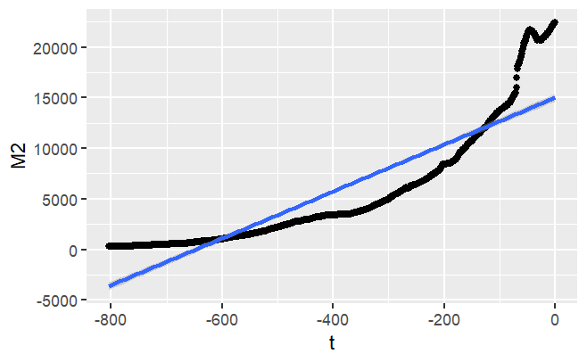

```
ggplot(ALL,aes(y=M1,x=t))+geom_point()+geom_smooth(method="lm")
```

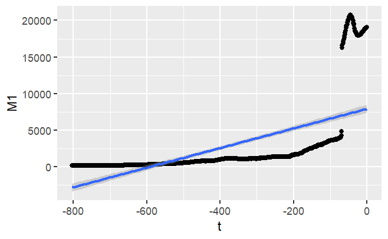

```
ggplot(ALL,aes(y=C,x=t))+geom_point()+geom_smooth(method="lm")
```

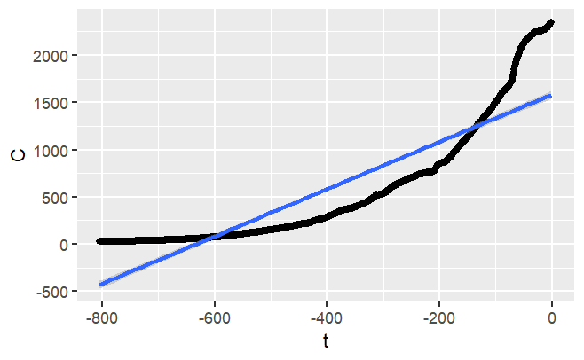

When visualizing the relationship, we might wish to have the dates on the x-axis instead. That is where using `index(ALL)` as the predictor can be more beneficial. You can see that the modeled relationships are identical, regardless of which time variable is used. The extra `xlab("")` at the end overrides the default x axis label, which would display index(ALL), which doesn’t add any value to the graphs.

```
ggplot(ALL,aes(y=M2,x=index(ALL)))+geom_point()+geom_smooth(method="lm")+xlab("")
```

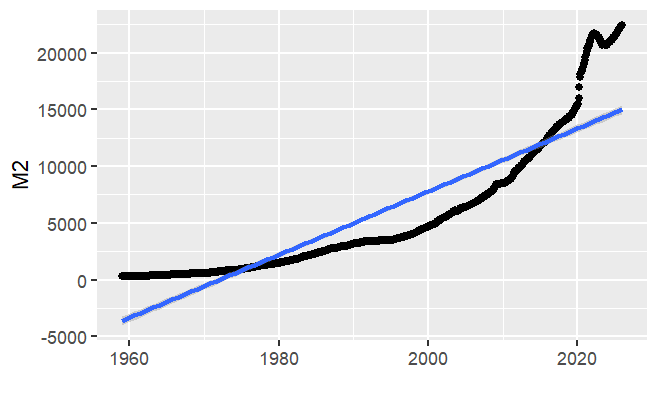

```
ggplot(ALL,aes(y=M1,x=index(ALL)))+geom_point()+geom_smooth(method="lm")+xlab("")
```

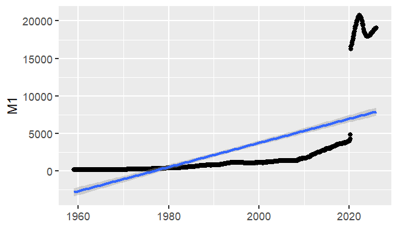

```
ggplot(ALL,aes(y=C,x=index(ALL)))+geom_point()+geom_smooth(method="lm")+xlab("")
```

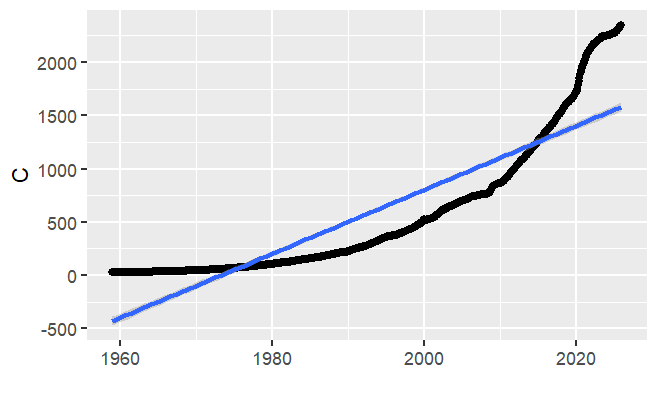

To evaluate the fit of our model and whether any assumptions have been violated, we should examine the residuals (errors). We’ll extract these from the linear models using the `resid()` function, and then replace the y-values in the plot with the residual values. This effectively adjusts the plots above to where the fitted blue line is horizontal, as shown below.

```
ggplot(ALL,aes(y=resid(lintrend_M2),x=index(ALL)))+geom_point()+geom_smooth(method="lm")+xlab("")
```

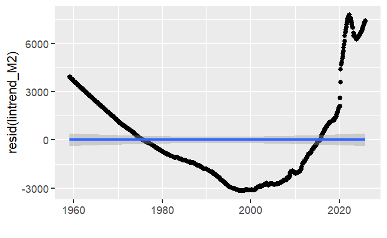

```
ggplot(ALL,aes(y=resid(lintrend_M1),x=index(ALL)))+geom_point()+geom_smooth(method="lm")+xlab("")
```

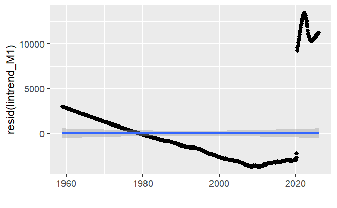

```
ggplot(ALL,aes(y=resid(lintrend_C),x=index(ALL)))+geom_point()+geom_smooth(method="lm")+xlab("")
```

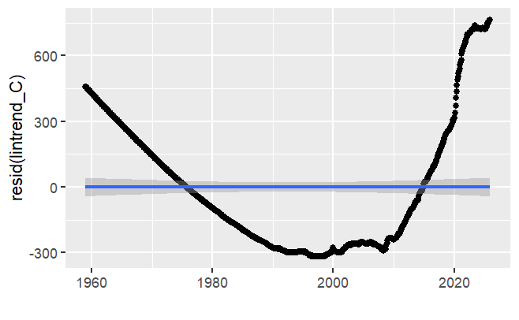

From those residual plots, there is very clear serial correlation and non-randomness in the errors. This suggests functional mis-specification of the model. See Chapter 7 regarding OLS assumptions, particularly Assumption 4, which discusses serial correlation.

To directly test for serial correlation, we’ll use the autocorrelation function (ACF) and partial autocorrelation function (PACF). The ACF effectively measures the correlation between $e_t$ and $e_{t−1}$, and then for $e_t$ and $e_{t−2}$, and so on for as many lags as desired. The PACF is similar to the ACF, except it produces the estimates of each lag after controlling for all shorter lags. In other words, rather than measuring the correlation between $e_t$ and $e_{t−2}$, we’d measure the linear regression coefficient for the second lag from a regression including both the first and second lags.

```
acf(resid(lintrend_M2))
```

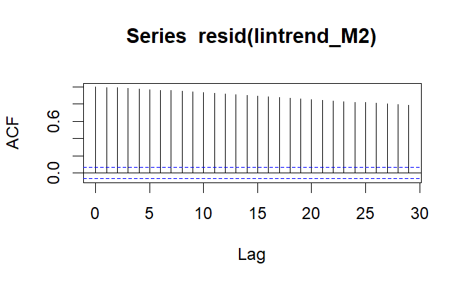

```
pacf(resid(lintrend_M2))
```

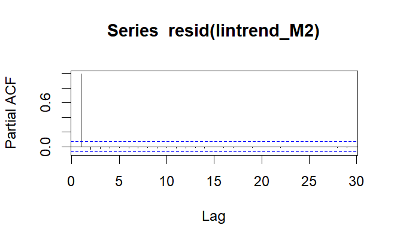

```
acf(resid(lintrend_M1))
```

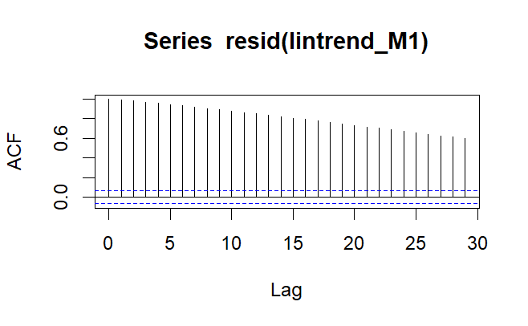

```
pacf(resid(lintrend_M1))
```

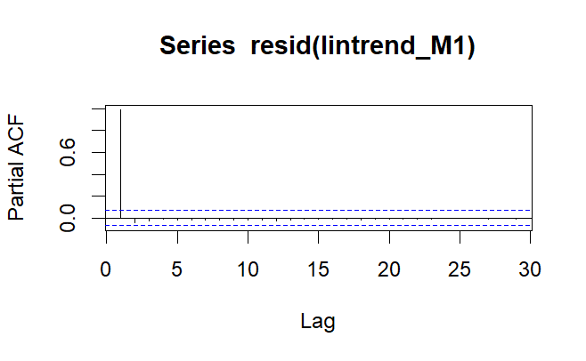

```
acf(resid(lintrend_C))
```

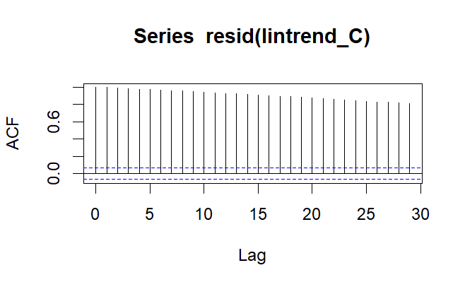

```
pacf(resid(lintrend_C))
```

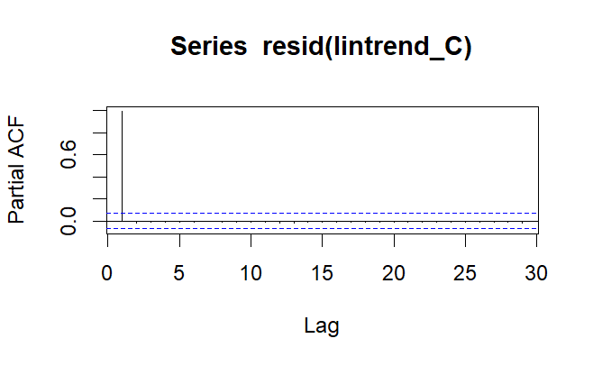

From the plots, we can see that the ACFs for each set of residuals greatly exceeds the dashed blue error bands. Thus, we’ve documented the clear autocorrelation (serial dependence) in the residuals.

### Logarithmic Trend Model

The first step towards addressing this is to take the natural logarithm of the money supply measures. Effectively, this can be thought of as shifting the units from dollars to “percents” (the next step will be to difference the values to get to “percent changes” in dollars or log returns).

```
ALL$logM2 = log(ALL$M2)
ALL$logM1 = log(ALL$M1)
ALL$logC = log(ALL$C)
```

When running the logarithmic trend models, we can either replace the y variable with our logged variable, or we can even apply the `log()` function within the `lm()` function, as done in the last line of this code chunk.

```
logtrend_M2 = lm(logM2~t, data=ALL)
logtrend_M1 = lm(logM1~t, data=ALL)
logtrend_C = lm(log(C)~t, data=ALL)
```

Now when we plot the fitted relationships, we see that the linear relationship fits much more closely after logging the y variable.

```
ggplot(ALL,aes(y=logM2,x=index(ALL)))+geom_point()+geom_smooth(method="lm")+xlab("")
```

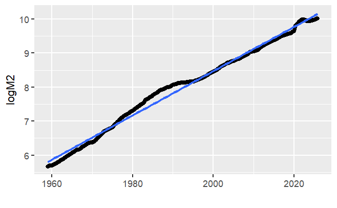

```
ggplot(ALL,aes(y=logM1,x=index(ALL)))+geom_point()+geom_smooth(method="lm")+xlab("")
```

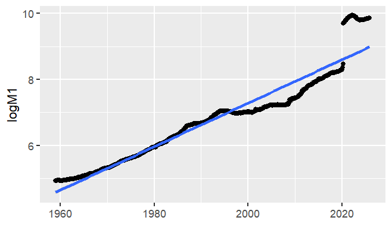

```
ggplot(ALL,aes(y=logC,x=index(ALL)))+geom_point()+geom_smooth(method="lm")+xlab("")
```

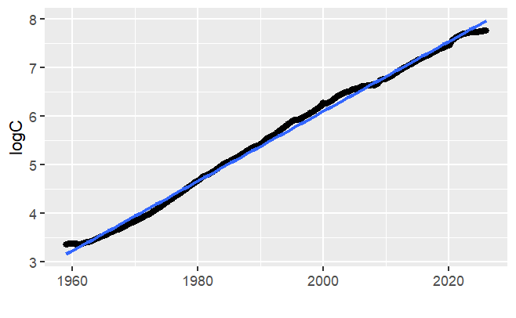

If we examine the residuals, these look a bit better than the previous regressions on the money supply levels. However, there still appears to be some autocorrelation present.

```
ggplot(ALL,aes(y=resid(logtrend_M2),x=index(ALL)))+geom_point()+geom_smooth(method="lm")+xlab("")
```

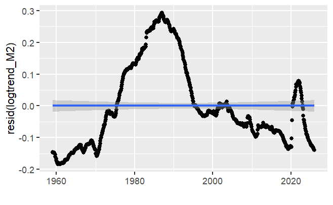

```
ggplot(ALL,aes(y=resid(logtrend_M1),x=index(ALL)))+geom_point()+geom_smooth(method="lm")+xlab("")
```

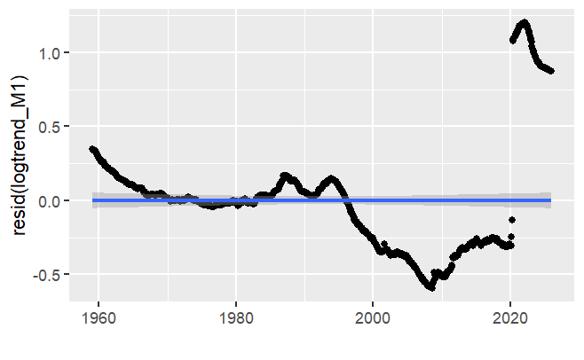

```
ggplot(ALL,aes(y=resid(logtrend_C),x=index(ALL)))+geom_point()+geom_smooth(method="lm")+xlab("")
```

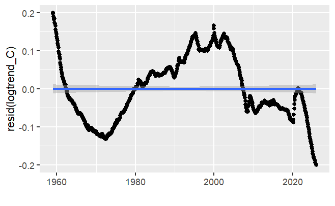

Now generate the ACF and PACF for the logarithmic trend models. These show that there still is substantial serial correlation present in the residuals.

```
acf(resid(logtrend_M2))
```

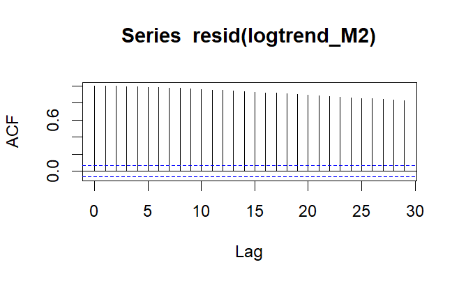

```
pacf(resid(logtrend_M2))
```

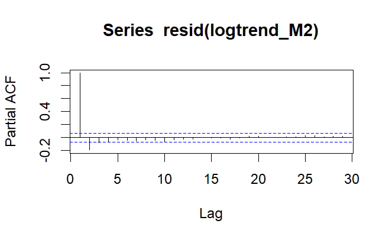

```
acf(resid(logtrend_M1))
```

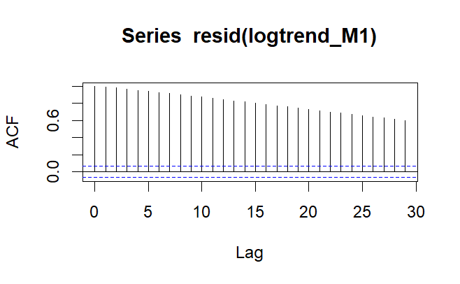

```
pacf(resid(logtrend_M1))
```

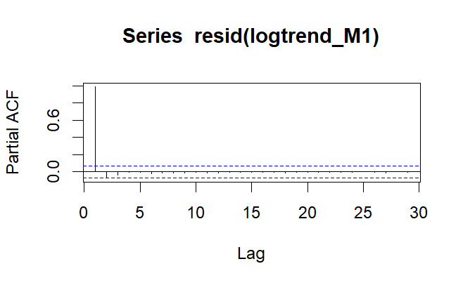

```
acf(resid(logtrend_C))
```

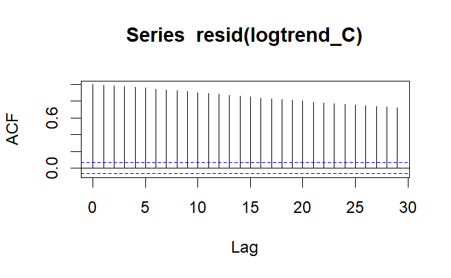

```
pacf(resid(logtrend_C))
```

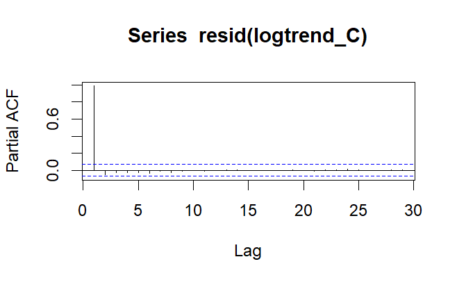

### Log Return Trend Model

The way to address the issue of serial correlation here is also the final step in transforming the money supply levels into continuously compounded growth rates. This is done by differencing the logged values from their prior observation’s logged value. This can be done with the `diff()` function. *Note: when differencing observations, the earliest observation is lost since we do not have a prior value and is replaced by `NA`.*

```
ALL$retM2 = diff(ALL$logM2)
ALL$retM1 = diff(ALL$logM1)
ALL$retC = diff(ALL$logC)
```

These differenced logs give us the continuously compounded monthly growth rate of each money supply measurement. If we regress these growth rates on a time trend,

```
rettrend_M2 = lm(retM2~t, data=ALL)
summary(rettrend_M2)
```

```
Call:
lm(formula = retM2 ~ t, data = ALL)

Residuals:
      Min        1Q    Median        3Q       Max
-0.019130 -0.002285 -0.000276  0.001657  0.056807

Coefficients:
              Estimate Std. Error t value Pr(>|t|)
(Intercept)  4.366e-03  3.195e-04   13.66  < 2e-16 ***
t           -2.644e-06  6.885e-07   -3.84 0.000133 ***
---
Signif. codes:  0 ‘***’ 0.001 ‘**’ 0.01 ‘*’ 0.05 ‘.’ 0.1 ‘ ’ 1

Residual standard error: 0.004523 on 801 degrees of freedom
  (1 observation deleted due to missingness)
Multiple R-squared:  0.01808,   Adjusted R-squared:  0.01685
F-statistic: 14.75 on 1 and 801 DF,  p-value: 0.0001326
```

```
rettrend_M1 = lm(retM1~t, data=ALL)
summary(rettrend_M1)
```

```
Call:
lm(formula = retM1 ~ t, data = ALL)

Residuals:
     Min       1Q   Median       3Q      Max
-0.04113 -0.00613 -0.00094  0.00249  1.20751

Coefficients:
             Estimate Std. Error t value Pr(>|t|)
(Intercept) 1.070e-02  3.079e-03   3.476 0.000536 ***
t           1.137e-05  6.635e-06   1.714 0.086977 .
---
Signif. codes:  0 ‘***’ 0.001 ‘**’ 0.01 ‘*’ 0.05 ‘.’ 0.1 ‘ ’ 1

Residual standard error: 0.04358 on 801 degrees of freedom
  (1 observation deleted due to missingness)
Multiple R-squared:  0.003653,  Adjusted R-squared:  0.002409
F-statistic: 2.937 on 1 and 801 DF,  p-value: 0.08698
```

```
rettrend_C = lm(retC~t, data=ALL)
summary(rettrend_C)
```

```
Call:
lm(formula = retC ~ t, data = ALL)

Residuals:
       Min         1Q     Median         3Q        Max
-0.0187231 -0.0020810  0.0001084  0.0018314  0.0191393

Coefficients:
              Estimate Std. Error t value Pr(>|t|)
(Intercept)  5.487e-03  2.358e-04   23.27   <2e-16 ***
t           -9.958e-09  5.082e-07   -0.02    0.984
---
Signif. codes:  0 ‘***’ 0.001 ‘**’ 0.01 ‘*’ 0.05 ‘.’ 0.1 ‘ ’ 1

Residual standard error: 0.003338 on 801 degrees of freedom
  (1 observation deleted due to missingness)
Multiple R-squared:  4.793e-07, Adjusted R-squared:  -0.001248
F-statistic: 0.0003839 on 1 and 801 DF,  p-value: 0.9844
```

If we examine the modeled relationships now, we see that the slope of the time trend is close to zero across each measurement of the money supply. This suggests that there isn’t a systematic long-term trend of accelerating growth. However, we can still see many outliers around major financial crises.

```
ggplot(ALL,aes(y=retM2,x=index(ALL)))+geom_point()+geom_smooth(method="lm")+xlab("")
```

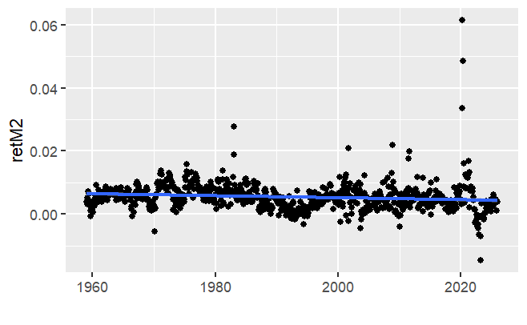

```
ggplot(ALL,aes(y=retM1,x=index(ALL)))+geom_point()+geom_smooth(method="lm")+xlab("")
```

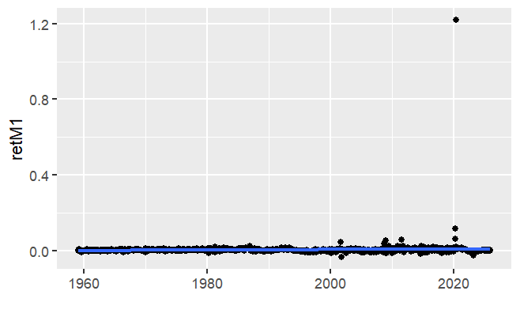

```
ggplot(ALL,aes(y=retC,x=index(ALL)))+geom_point()+geom_smooth(method="lm")+xlab("")
```

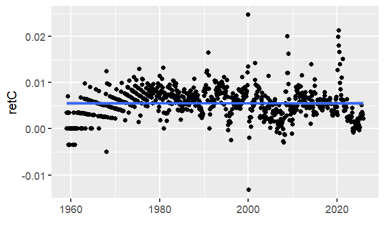

Now to examine the residuals. The `ALL[-1,]` here resolves an error that arose from the missing value due to differencing. Since the slopes are nearly zero, these residuals are very similar to the above regression plots.

```
ggplot(ALL[-1,],aes(y=resid(rettrend_M2),x=index(ALL[-1,])))+geom_point()+geom_smooth(method="lm")+xlab("")
```

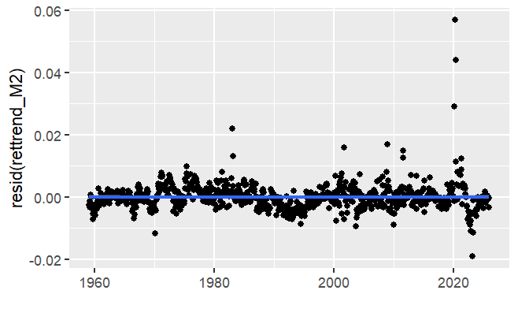

```
ggplot(ALL[-1,],aes(y=resid(rettrend_M1),x=index(ALL[-1,])))+geom_point()+geom_smooth(method="lm")+xlab("")
```

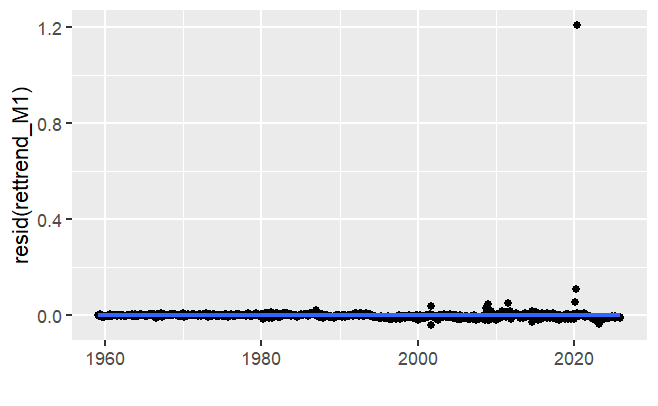

```
ggplot(ALL[-1,],aes(y=resid(rettrend_C),x=index(ALL[-1,])))+geom_point()+geom_smooth(method="lm")+xlab("")
```

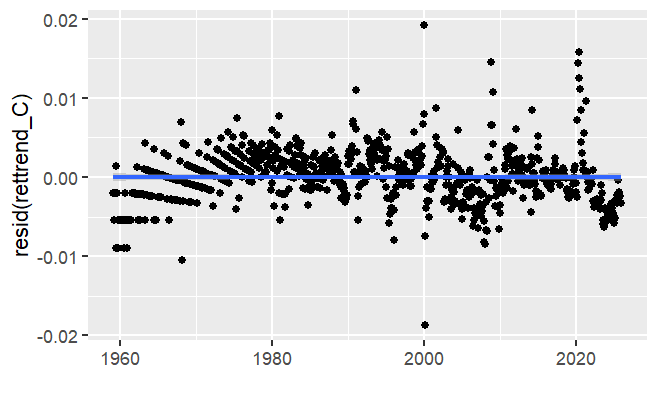

Now we plot the ACF and PACF plots:

```
acf(resid(rettrend_M2))
```

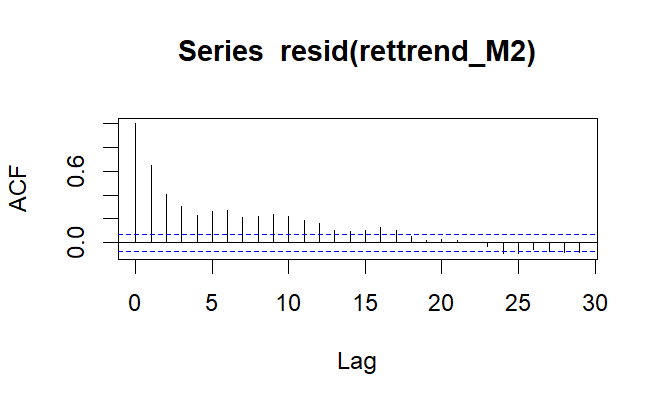

```
pacf(resid(rettrend_M2))
```

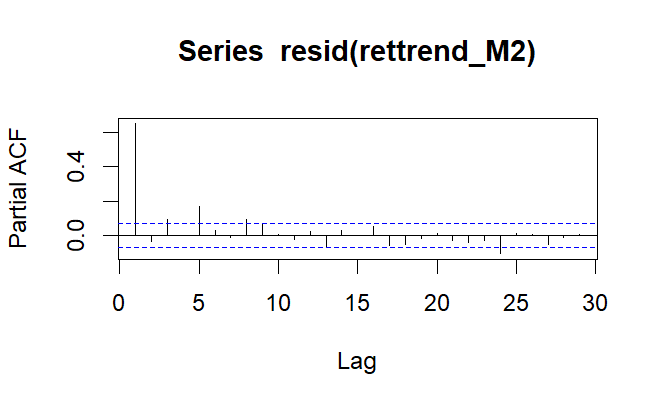

```
acf(resid(rettrend_M1))
```

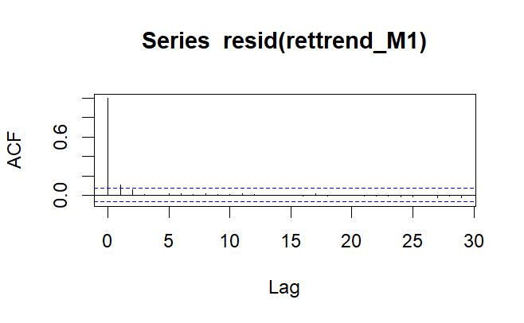

```
pacf(resid(rettrend_M1))
```

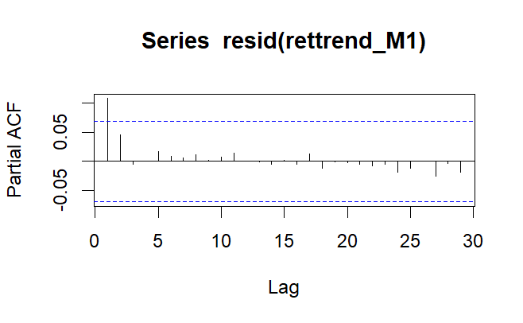

```
acf(resid(rettrend_C))
```

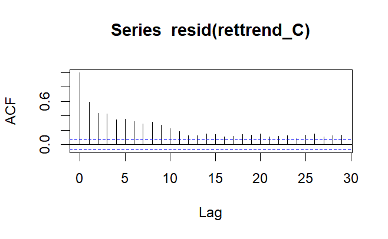

```
pacf(resid(rettrend_C))
```

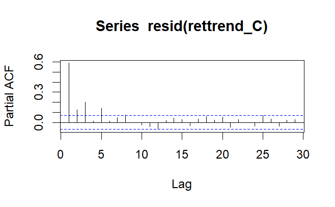

So there is still some significant values in the ACFs and PACFs, but we have certainly made substantial progress at reducing serial correlation in the model by transforming the dollar values into log returns. The next step would be to begin incorporating relevant economic factors into the regression model to further explain the increases in the money supply.

### Additional Insights

One additional insight gained from the log return models is that the intercept term measures the model’s current estimate of monthly growth. To convert this to an annualized growth rate, we multiply the intercept estimate by 12.

```
rettrend_M2$coefficients[1]*12
```

```
(Intercept)
 0.05238832
```

```
rettrend_M1$coefficients[1]*12
```

```
(Intercept)
  0.1284356
```

```
rettrend_C$coefficients[1]*12
```

```
(Intercept)
 0.06584986
```

Before we wrap up, let’s revisit the question of how much of an outlier 2020 was in a historical context. From our log return models, let’s convert the residuals into z-scores by subtracting the mean (which is 0 by construction of linear regression) and dividing by the standard deviation.

```
Z = data.frame(date=index(ALL[-1,]))
e_mu_M2 = mean(rettrend_M2$residuals)
e_sd_M2 = sd(rettrend_M2$residuals)
Z$M2 = (rettrend_M2$residuals-e_mu_M2)/e_sd_M2
e_mu_M1 = mean(rettrend_M1$residuals)
e_sd_M1 = sd(rettrend_M1$residuals)
Z$M1 = (rettrend_M1$residuals-e_mu_M1)/e_sd_M1
e_mu_C = mean(rettrend_C$residuals)
e_sd_C = sd(rettrend_C$residuals)
Z$C = (rettrend_C$residuals-e_mu_C)/e_sd_C
```

Working off of the assumption that the errors (residuals) are normally distributed, we can use these z-scores to identify outliers.

```
ggplot(Z,aes(y=M2,x=date))+geom_point()+geom_smooth(method="lm")
```

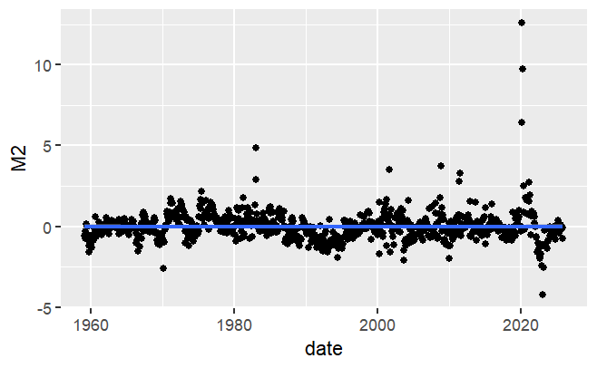

```
ggplot(Z,aes(y=M1,x=date))+geom_point()+geom_smooth(method="lm")
```

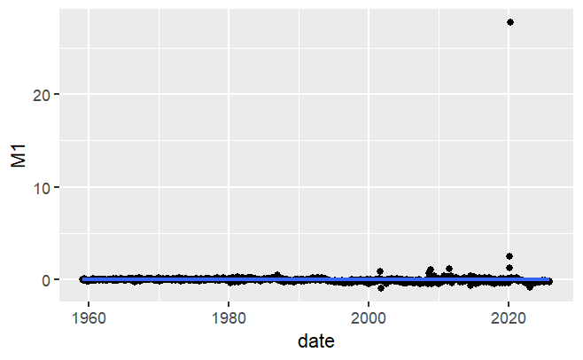

```
ggplot(Z,aes(y=C,x=date))+geom_point()+geom_smooth(method="lm")
```

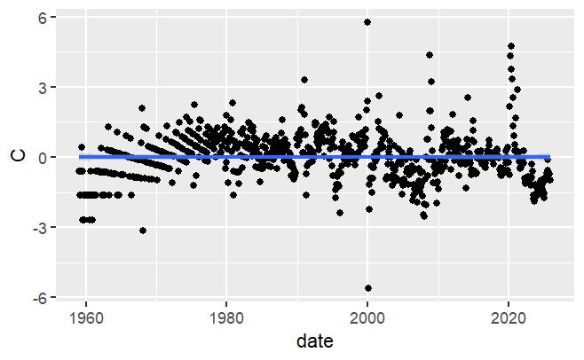

If we consider the residuals of the log return model to be normally distributed, then we would expect that z>3 in less than 1% of observations, and z>5 would almost never occur. Lets count how many exceed those thresholds.

```
sum(Z$M2>3)
```

```
[1] 7
```

```
sum(Z$M1>3)
```

```
[1] 1
```

```
sum(Z$C>3)
```

```
[1] 8
```

```
sum(Z$M2>5)
```

```
[1] 3
```

```
sum(Z$M1>5)
```

```
[1] 1
```

```
sum(Z$C>5)
```

```
[1] 1
```

Now let’s count how many of those occurred in 2020.

```
sum(Z$M2[732:744]>3)
```

```
[1] 3
```

```
sum(Z$M1[732:744]>3)
```

```
[1] 1
```

```
sum(Z$C[732:744]>3)
```

```
[1] 4
```

```
sum(Z$M2[732:744]>5)
```

```
[1] 3
```

```
sum(Z$M1[732:744]>5)
```

```
[1] 1
```

```
sum(Z$C[732:744]>5)
```

```
[1] 0
```